# Clustering different data sources:

## 1. Loading the data sources

### 1.1 CSV files

### 1.2 Web Scraping of a suspicious website.

## 2. Normalizing the data sources

### 2.1 Values only after 1972

### 2.2 Normalized all data sources on a scale of 1 to 100

## 3. Plotting normalized Data Sources

## 4. Creating a model(Feature Selection-like)

### 4.1 Mean, Median of different distance algorithms

### 4.2 Plugging all the values into a dataframe

### 5. Clustering

### 5.1 Using Gaussian Mixture Model

### 5.2 Final Clusters

## [1. Loading the data sources]

```python
import pandas as pd
import numpy as np
```

## [1.1 CSV files]

```python
datahub=pd.read_csv("datahub.csv");
macrotrends=pd.read_csv("macrotrends.csv");
social_weather=pd.read_csv("SW_quandl.csv");
```

### [1.2 Web Scraping of a suspicious website.]

```python
from bs4 import BeautifulSoup
import urllib.request
ra = urllib.request.urlopen("http://www.multpl.com/s-p-500-historical-prices/table/by-year")
r=ra.read()
soup = BeautifulSoup(r)
print(type(soup))
#print(soup.prettify()[0:1000000])
```

```
<class 'bs4.BeautifulSoup'>
```

```python
import numbers
#a=soup.table
trs=soup.findAll('tr')
#b=a[0].next_element
#print(b)
#i=0;
date=[]
value=[]
tables = soup.findAll("table")

for table in tables:
    if table.findParent("table") is None:
        a=str(table)
        soup2 = BeautifulSoup(a)
        for row in soup2.find_all("tr")[1:]:  #row by row
            col = row.find_all("td") # differentiating the td into columns.
            col = [ele.text.strip() for ele in col]
            #i=i+1;
            #print(i)
            try:                     #trying to convert them into strings.
                date.append(str(col[0]))
                value.append(float(col[1].replace(',', '')))
                #spam.append(str(col[3])) ## I could've put them in a for loop
                # but then I would have to rewrite the code for try and except
            except OSError as err:
                print("OS error: {0}".format(err))
            except ValueError:
                print("Expected a string and got something else")
            except:
                print("Unexpected error:", sys.exc_info()[0])
                raise
                #print(col)
                print("---")
            #print(spam)
print(len(date))
print(len(value))
```

```
149
149
```

```python
new_dF=pd.DataFrame(value,date,columns=['multpl_SP500'])
# convert it to datetime format so I can extract the year
new_dF.index=new_dF.index.to_datetime()
#remove the most recent one as we have data only till 2018.
new_dF=new_dF[1:]
new_dF.index=new_dF.index.year
#-1 as the author has shown the dates as January 1st instead of December 31st
new_dF.index=new_dF.index-1
# set the name of the index column
new_dF.index.rename('date', inplace=True)
#take values after 1971
multpl=new_dF[new_dF.index>1971]
multpl=multpl
```

```python
datasource_names=['macrotrends','datahub','multpl'];
datasource_type=['percent_change','actual_val','actual_val'];
datasources=[macrotrends, datahub, multpl];
```

## [2. Normalizing the data sources]

### [2.1 Values only after 1972]

### I would only be checking the values from 1972 because that is where the APIs of quandl started.

This would be already computed and in the database: (Social Weather) I wouldn't really ask for the granularity , I would group them by year itself? Great? Maybe not, but a start.

```python
social_weather["date"]=pd.to_datetime(social_weather["date"])
social_weather=social_weather[(social_weather["date"].dt.year>1971) & (social_weather["date"].dt.year < 2018)];
social_weather=social_weather.groupby(social_weather["date"].dt.year).mean();
print(social_weather.describe());
```

```
         SW_SP500
count   46.000000
mean    31.300808
std     26.763327
min      3.383571
25%      6.575750
50%     20.533769
75%     49.898737
max    100.000000
```

These are the new csv files or json docs, which would be uploaded:

```python
import datetime as dt
for x in range(0,len(datasources)-1):
    dF=datasources[x];
    dF["date"]=pd.to_datetime(dF["date"]);
    dF=dF[(dF["date"].dt.year>1971) & (dF["date"].dt.year < 2018)]
    dF["date"]=dF["date"].dt.year
    dF=dF.groupby(dF["date"]).mean();
    datasources[x]=dF;
    print(datasource_names[x]);
    print(datasources[x].describe());
```

```
macrotrends
       macro_SP500
count    46.000000
mean      8.751739
std      16.021846
min     -33.840000
25%      -1.825000
50%      11.435000
75%      20.307500
max      38.320000
datahub
       datahub_SP500
count      46.000000
mean      763.861322
std       653.453690
min        82.552500
25%       160.435417
50%       500.983750
75%      1217.431458
max      2448.217500
```

```python
datasources[x+1].describe()
```

|  | multpl_SP500 |
| --- | --- |
| count | 46.000000 |
| mean | 796.896522 |
| std | 690.995555 |
| min | 72.560000 |
| 25% | 167.700000 |
| 50% | 543.705000 |
| 75% | 1281.647500 |
| max | 2789.800000 |

```python
len(multpl)
```

```
46
```

### [2.2 Normalized all data sources on a scale of 1 to 100]

We will have have to normalize all of the data sources. I had normalized my datasource to a scale of 0 to 100, with 100 being the highest stock market count.

Macrotrends, has a change of stock value to the prior year as a percent. So if the stock price went up by 50%, the price would go to +50%, if there is a drop in stocks by 16%, then the price would drop by -15%.

Datahub, is the actual price level itself, similar to what I had before I had normalized it down to a 100 scale in the Quandl dataset.

### Let's get all of them to a scale of 100!

### Macrotrends: ( change percent each year.)

By the rule of hand, always start with the harder one.

There are many ways we can go about this. Well, ((after value – before value) / before value) * 100 = % change

I will be selecting my own primary source from social weather to make it the first value. After which, I will use the formula to calculate it it.

```python
all_sources=pd.concat([datasources[0],social_weather], axis=1)
for x in range(1,len(datasources)):
    all_sources=pd.concat([datasources[x],all_sources], axis=1)
```

```python
all_sources.head()
```

| date | multpl_SP500 | datahub_SP500 | macro_SP500 | SW_SP500 |
| --- | --- | --- | --- | --- |
| 1972 | 118.40 | 109.208333 | 14.58 | 4.476111 |
| 1973 | 96.11 | 107.423333 | -16.58 | 4.402949 |
| 1974 | 72.56 | 82.552500 | -27.57 | 3.383571 |
| 1975 | 96.86 | 86.155833 | 38.32 | 3.531260 |
| 1976 | 103.80 | 102.021667 | 17.86 | 4.181551 |

```python
all_sources.tail()
```

| date | multpl_SP500 | datahub_SP500 | macro_SP500 | SW_SP500 |
| --- | --- | --- | --- | --- |
| 2013 | 1822.36 | 1642.511667 | 26.50 | 67.321455 |
| 2014 | 2028.18 | 1930.667500 | 7.52 | 79.132068 |
| 2015 | 1918.60 | 2061.199167 | -2.23 | 84.482156 |
| 2016 | 2275.12 | 2091.844167 | 13.42 | 85.738200 |
| 2017 | 2789.80 | 2448.217500 | 25.08 | 100.000000 |

```python
all_sources.columns
```

```
Index(['multpl_SP500', 'datahub_SP500', 'macro_SP500', 'SW_SP500'], dtype='object')
```

I would ask the user about how the data is represented? I can't make an assumption. I have taken three examples in the synthetic data. Complete Value- Datahub, Percent change- macrotrends ,Normalized- Social Weather(Trusted).

```python
def actual_val_norm(current_col):
    dF_norm=(all_sources[current_col]/all_sources[current_col].max())*100
    return dF_norm;

def percent_change_norm(current_col):
    #Let's take the database with the highest external reliability:
    before_value=all_sources[all_sources.columns[col_total-1]].loc[1972]
    for x in range(1973,2018):
        all_sources[current_col].loc[x-1]=before_value
        change=all_sources[current_col].loc[x]
        #print(change)
        #print([all_sources.columns[col_total-1]])
        after_value=((change * before_value)/100)+before_value
        before_value=after_value
        #print(after_value,x)
    all_sources[current_col].loc[x]=before_value
    return;
```

```python
col_total=len(all_sources.columns)
for x in range(1,len(all_sources.columns)):
    current_col=all_sources.columns[col_total-(x+1)]
    if((datasource_type[x-1])=='percent_change'):
        #print("percent_change",current_col)
        percent_change_norm(current_col)
        all_sources[current_col]=actual_val_norm(current_col)
        #print(all_sources[current_col]);
    elif((datasource_type[x-1])=='actual_val'):
        #print("actual_val",current_col)
        all_sources[current_col]=actual_val_norm(current_col);
        #print(all_sources[current_col]);
        #print(all_sources[current_col])
        #print((all_sources[current_col]/all_sources[current_col].max())*100) # You could even do min-max.. Anything is good.
```

```python
all_sources.head()
```

| date | multpl_SP500 | datahub_SP500 | macro_SP500 | SW_SP500 |
| --- | --- | --- | --- | --- |
| 1972 | 4.244032 | 4.460728 | 4.126498 | 4.476111 |
| 1973 | 3.445050 | 4.387818 | 3.442324 | 4.402949 |
| 1974 | 2.600903 | 3.371943 | 2.493276 | 3.383571 |
| 1975 | 3.471933 | 3.519125 | 3.448699 | 3.531260 |
| 1976 | 3.720697 | 4.167181 | 4.064636 | 4.181551 |

## Something doesn't seem right. Let's ignore this, it seems macrotrends has not leveled the prices, not cool by macrotrends, they never mentioned it, but well, let's move on.

## [3. Plotting normalized Data Sources]

```python
all_sources.corr() # the correlation is strong, it could be because the variation is extremely similar.
```

|  | multpl_SP500 | datahub_SP500 | macro_SP500 | SW_SP500 |
| --- | --- | --- | --- | --- |
| multpl_SP500 | 1.000000 | 0.989302 | 0.996573 | 0.989204 |
| datahub_SP500 | 0.989302 | 1.000000 | 0.990602 | 0.999998 |
| macro_SP500 | 0.996573 | 0.990602 | 1.000000 | 0.990509 |
| SW_SP500 | 0.989204 | 0.999998 | 0.990509 | 1.000000 |

### By looking at the data and the graph itself I can see that the Social Weather and Datahub are much more similar, than multpl(Bad source) and macrotrends(not it's fault, it's not a level price, means that it's the actual price of the stock(patterns are the same.)

### I would want Social Weather and Datahub in one cluster. The others in their own cluster.

### For the sake of now, I haven't taken any external review into account.

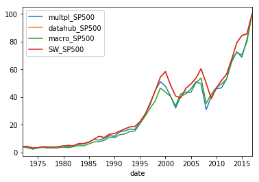

```python
import matplotlib.pyplot as plt
all_sources.plot(legend=True)
plt.show()
#Social weather and datahub are
```